# A Bayesian adaptive design for dual-agent phase I-II cancer clinical trials combining efficacy data across stages

José L. Jiménez (jose_luis.jimenez@novartis.com) and Haiyan Zheng (haiyan.zheng@mrc-bsu.cam.ac.uk)

In this R Notebook, we show step-by-step how to run *one* simulated trial.

We start with the libraries, seed and user-defined functions.

```r
library(rjags)
library(tidyverse)

rm(list=ls())

set.seed(1234)

# This function simulates a binary DLT responses for stages 1 and 2.
resp_safety_st1 = function(rho00 = trho00_st1, rho01 = trho01_st1, rho10 = trho10_st1, alpha3 = talpha3_st1, x, y){
  alpha0 = log(rho00/(1-rho00))
  alpha1 = log(rho10/(1-rho10)) - log(rho00/(1-rho00))
  alpha2 = log(rho01/(1-rho01)) - log(rho00/(1-rho00))
  p = 1/(1+exp(-alpha0-alpha1*x-alpha2*y-alpha3*x*y))
  u = runif(1)
  z = ifelse(u < p, 1, 0)
  return(z)
}
resp_safety_st2 = function(rho00 = trho00_st2, rho01 = trho01_st2, rho10 = trho10_st2, alpha3 = talpha3_st2, x, y){
  alpha0 = log(rho00/(1-rho00))
  alpha1 = log(rho10/(1-rho10)) - log(rho00/(1-rho00))
  alpha2 = log(rho01/(1-rho01)) - log(rho00/(1-rho00))
  p = 1/(1+exp(-alpha0-alpha1*x-alpha2*y-alpha3*x*y))
  u = runif(1)
  z = ifelse(u < p, 1, 0)
  return(z)
}

# This function simulates a binary efficacy responses for stages 1 and 2.
resp_efficacy_st1 = function(beta0 = tbeta0_st1, beta1 = tbeta1_st1, beta2 = tbeta2_st1, beta3 = tbeta3_st1, x, y){
  p = exp(beta0+exp(beta1)*x+exp(beta2)*y+beta3*x*y) / (1 + exp(beta0+exp(beta1)*x+exp(beta2)*y+beta3*x*y))
  u = runif(1)
  z = ifelse(u < p, 1, 0)
  return(z)
}
resp_efficacy_st2 = function(beta0 = tbeta0_st2, beta1 = tbeta1_st2, beta2 = tbeta2_st2, beta3 = tbeta3_st2, x, y){
  p = exp(beta0+exp(beta1)*x+exp(beta2)*y+beta3*x*y) / (1 + exp(beta0+exp(beta1)*x+exp(beta2)*y+beta3*x*y))
  u = runif(1)
  z = ifelse(u < p, 1, 0)
  return(z)
}

# This function computes the probability of DLT at dose combination (x,y)
pdlt = function(rho00,rho01,rho10,alpha3,x,y){
  alpha0 = log(rho00/(1-rho00))
  alpha1 = log(rho10/(1-rho10)) - log(rho00/(1-rho00))
  alpha2 = log(rho01/(1-rho01)) - log(rho00/(1-rho00))
  p = 1/(1+exp(-alpha0-alpha1*x-alpha2*y-alpha3*x*y))
  return(p)
}

# This function computes the probability of efficacy at dose combination (x,y)
peff = function(beta0,beta1,beta2,beta3,x,y){
  p = exp(beta0+exp(beta1)*x+exp(beta2)*y+beta3*x*y) / (1 + exp(beta0+exp(beta1)*x+exp(beta2)*y+beta3*x*y))
  return(p)
}

# This function finds the set of MTD set
twodimmtd2 = function(rho00,rho01,rho10,alpha3,theta,x){

  alpha0 = log(rho00/(1-rho00))
  alpha1 = log(rho10/(1-rho10)) - log(rho00/(1-rho00))
  alpha2 = log(rho01/(1-rho01)) - log(rho00/(1-rho00))

  a = (log(theta/(1-theta))-alpha0-alpha1*x)/(alpha2+alpha3*x)

  return(a)
}
```

The functions *resp_safety_st1* and *resp_safety_st2* generate binary safety outcomes and the functions *resp_efficacy_st1* and *resp_efficacy_st2* generate binary efficacy outcomes from the true underlying dose-toxicity and dose-efficacy models, respectively. These two functions require as input the **true** model parameters.

The functions *pdlt* and *peff* calculate the probability of having a dose limiting toxicity (DLT) outcome, and the probability of having an efficacy outcome, respectively. These two functions correspond to equations (1) and (5), respectively. However, recall that we reparametrize equation (1) in order to have model parameters that clinicians can easily interpret and therefore facilitate the elicitation of the prior distributions. Last, the function *twodimmtd2* calculates the 2-dimensional maximum tolerated dose (MTD) curve. This function corresponds to equation (3) in the manuscript and already incorporates the new parameters $\rho_{00}, \rho_{10}, \rho_{01}$ from the dose-toxicity model.

We now define all the design parameters, true dose-toxicity and dose-efficacy parameter models and declare all the necessary variable to run the simulated trial.

```r
# Controls size of dose escalation during stage I.
delta1 = 0.2

# Minimum and maximum doses available in the trial
# X dose is for Cabazitaxel
Xmin = 10
Xmax = 25
# Y dose is for Cisplatin
Ymin = 50
Ymax = 100

lbx  =  (0 - Xmin)/(Xmax - Xmin)
lby  =  (0 - Ymin)/(Ymax - Ymin)

qq = 101
x_grid = seq(0,1,length.out = qq)

# Threshold for posterior probability of toxicity at minimum dose for stopping trial
delta = 0.8

#True model parameters

# True parameters for safety in stage 1
trho00_st1<-1e-7
trho01_st1<-0.2
trho10_st1<-0.2
talpha3_st1<-10
# True parameters for safety in stage 2
trho00_st2 = trho00_st1
trho01_st2 = trho01_st1
trho10_st2 = trho10_st1
talpha3_st2 = talpha3_st1
#True parameters for efficacy is stage 1
tbeta0_st1 = -5
tbeta1_st1 = 0.75
tbeta2_st1 = 1.51
tbeta3_st1 = 0.5
#True parameters for efficacy is stage 2 (having the same dose-efficacy model parameters mean there is complete agreement across stages)
tbeta0_st2 = tbeta0_st1
tbeta1_st2 = tbeta1_st1
tbeta2_st2 = tbeta2_st1
tbeta3_st2 = tbeta3_st1

# Target Probability of DLT
theta = 1/3

#Efficacy from the standard of care
null_p = 0.15

# Number of patients in a trial
NN_1 = 30
NN_2_fixed = 10
NN_2 = 30 - NN_2_fixed
m_cohort = NN_2/5

# Feasibility bound (EWOC)
alpha = numeric()
alphaa = seq(0.4,0.5,by=0.05)
for (ind in 1:3){
  alpha[ind] = alphaa[ind]
}
for (ind in 4:(NN_1-1)){
  alpha[ind] = alphaa[3]
}

# vrho00 = numeric()
# vrho01 = numeric()
# vrho10 = numeric()
# valpha3 = numeric()
#
# vbeta0_st2 = numeric()
# vbeta1_st2 = numeric()
# vbeta2_st2 = numeric()
# vbeta3_st2 = numeric()
#
# vprob.ex = numeric()

#mcmc parameters

chains = 1
burn = 10000
mm = 5000

#Prior hyperparameters (stage 1)

a00 = 0.8
b00 = 7.2
a01 = 1.4
b01 = 5.6
a10 = 1.4
b10 = 5.6
a = 0.8
b = 0.0384


# # Declaration of intermediate statistics
# trcmtdx1 = numeric()
# trcmtdx2 = numeric()
# trcmtdy1 = numeric()
# trcmtdy1 = numeric()
#
# # Declaration of the output statistics
# optimal_dose_x = numeric()
# optimal_dose_y = numeric()
# dosex_st1 = mat.or.vec(1,NN_1)
# dosey_st1 = mat.or.vec(1,NN_1)
# dosex_st2 = mat.or.vec(1,(NN_2_fixed+NN_2))
# dosey_st2 = mat.or.vec(1,(NN_2_fixed+NN_2))
# interim_prob_eff = mat.or.vec(1,NN_2/m_cohort)
# posterior_prob_efficacy = mat.or.vec(1,qq)
# dlt_st1 = mat.or.vec(1,NN_1)
# eff_st1 = mat.or.vec(1,NN_1)
# eff_st2 = mat.or.vec(1,(NN_2_fixed+NN_2))
# max_posterior_prob_efficacy = numeric()
# target_dose = numeric()

interim_prob_dlt = numeric()
```

One variable that requires special attention is $w$, which control the prior believe around the similarity of the dose-efficacy profiles across stages (see equation (6) in the manuscript). By setting $w = 0$, we are stating there is **no similary** between the dose-efficacy profiles across stages whatsoever. In contrast, $w=1$ states the efficacy data across stages is completely exchangeable.

```r
w = 0.3
wMix = c(w,(1-w))

#How to define wMix:
# 100% non-exchangeability
#   wMix = c(0,1)
# 100% exchangeability
#   wMix = c(1,0)
# 50% exchangeability - 50% non-exchangeability
#   wMix = c(0.5,0.5)
```

Once all the model parameters are defined, let’s visualize how the true dose-toxicity and dose-efficacy underlying scenarios look like. First, we show the true MTD curve (i.e., dose combinations with a true probability of DLT equal to $\theta$).

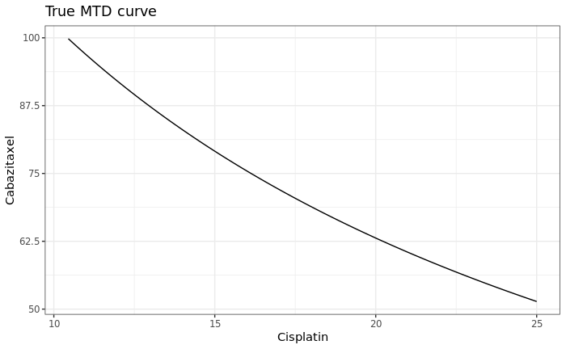

```r
#Probability of DLT scenario visualization

mtd_df = data.frame(x = x_grid) %>%
  mutate(y_mtd = twodimmtd2(trho00_st1, trho01_st1, trho10_st1, talpha3_st1,theta,x)) %>%
  filter(y_mtd <= 1)

ggplot(mtd_df, aes(x = x, y = y_mtd)) +
  geom_line() +
  scale_x_continuous("Cisplatin",breaks = c(0,1/3,2/3,1),labels = function(x){round(x*(Xmax - Xmin) + Xmin,0)}) +
  scale_y_continuous(name = "Cabazitaxel", labels = function(y){y*(Ymax - Ymin) + Ymin}) +
  theme_bw() +
  labs(title = "True MTD curve") +
  theme(legend.position = "none",
        legend.text = element_text(size = 9),
        legend.background = element_rect(fill="transparent"),
        legend.key = element_rect(fill="transparent"),
        legend.title=element_blank())
```

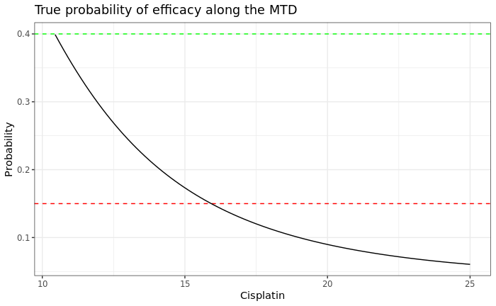

```r
peff_df = mtd_df %>%
   mutate(peff = peff(tbeta0_st2,tbeta1_st2,tbeta2_st2,tbeta3_st2,x,y_mtd))


ggplot(peff_df,aes(x = x, y = peff)) +
  geom_hline(yintercept = 0.15, linetype = "dashed", colour = "red", size = 0.5) +
  geom_hline(yintercept = 0.4, linetype = "dashed", colour = "green", size = 0.5) +
  geom_line() +
  scale_x_continuous("Cisplatin",breaks = c(0,1/3,2/3,1),labels = function(x){round(x*(Xmax - Xmin) + Xmin,0)}) +
  scale_y_continuous("Probability") +
  theme_bw() +
  labs(title = "True probability of efficacy along the MTD") +
  theme(legend.position = "none",
        legend.text = element_text(size = 9),
        legend.background = element_rect(fill="transparent"),
        legend.key = element_rect(fill="transparent"),
        legend.title=element_blank())
```

```r
NA
NA
```

```r
# data for first cohort of two patients

# First two patients will be given Cisplatin 75 mg/m2 and Cabazitaxel 15 mg/m2
doseX1 = c(0.3333333,0.3333333)
doseY1 = c(0.5,0.5)

# Simulate responses for patients 1 and 2 from logistic model

zz1 = resp_safety_st1(x = doseX1[1], y = doseY1[1])
zz2 = resp_safety_st1(x = doseX1[2], y = doseY1[2])
ee1 = resp_efficacy_st1(x = doseX1[1], y = doseY1[1])
ee2 = resp_efficacy_st1(x = doseX1[2], y = doseY1[2])
Z = c(zz1,zz2)
NEff.stg1 = c(ee1, ee2)
Ncomb1 = 2

data_jags = list('Z'= Z, 'X'= doseX1, 'Y'= doseY1, 'theta'= theta, 'N'= Ncomb1, 'a00' = a00, 'b00' = b00,
                 'a01' = a01, 'b01' = b01, 'a10' = a10, 'b10' = b10, 'a' = a, 'b' = b)

# Get dose Y for patient 3 when dose X equals 0 and dose X for patient 4 when dose Y equals 0
j=jags.model('stage1.bug.txt',data=data_jags,n.chains=chains,n.adapt=burn,quiet = TRUE)
s=coda.samples(j,c('mtdx1','mtdx2','mtdy1','mtdy2',"rho00","rho10","rho01","alpha3"),mm,progress.bar = "none")
ss=as.data.frame(s[[1]])

#Calculating posterior probability of toxicity at x = 0, y = 0.
  #We create, for each MCMC sample, the correspondent P(DLT).
  #We then calculate the mean posterior P(DLT) at x = 0, y = 0
  ss2 = ss %>% mutate(temp1 = pdlt(rho00,rho01,rho10,alpha3, x = 0, y = 0),
                      temp2 = ifelse(temp1 > theta + 0.1, 1, 0))

  interim_prob_dlt[1] = dplyr::pull(ss2 %>% summarise(m = mean(temp2)))

trcmtdx1 = ss$mtdx1[ss$mtdx1 > lbx]
xx1 = max(0,quantile(trcmtdx1,alpha[1]))
xx1 = min(xx1,1)
if ((xx1 - doseX1[1]) > delta1)
  xx1 = doseX1[1]+delta1

trcmtdy2 = ss$mtdy2[ss$mtdy2 > lby]
yy2 = max(0,quantile(trcmtdy2,alpha[1]))
yy2 = min(yy2,1)
if ((yy2 - doseY1[2]) > delta1)
  yy2 = doseY1[2]+delta1

# Update data
doseX1 = c(doseX1,0,xx1)
doseY1 = c(doseY1,yy2,0)

# Simulate responses for patients 3 and 4 from logistic model
zz1 = resp_safety_st1(x = doseX1[3], y = doseY1[3])
zz2 = resp_safety_st1(x = doseX1[4], y = doseY1[4])
ee1 = resp_efficacy_st1(x = doseX1[3], y = doseY1[3])
ee2 = resp_efficacy_st1(x = doseX1[4], y = doseY1[4])
Z = c(Z,zz1,zz2)
NEff.stg1 = c(NEff.stg1, ee1, ee2)
Ncomb1 = 4

data_jags = list('Z'= Z, 'X'= doseX1, 'Y'= doseY1, 'theta'= theta, 'N'= Ncomb1, 'a00' = a00, 'b00' = b00,
                 'a01' = a01, 'b01' = b01, 'a10' = a10, 'b10' = b10, 'a' = a, 'b' = b)

for (c1 in 3:(NN_1/2)) {

    j=jags.model('stage1.bug.txt',data=data_jags,n.chains=chains,n.adapt=burn,quiet = TRUE)
    s=coda.samples(j,c('rho00','rho01','rho10','alpha3','mtdx1','mtdy1','mtdx2','mtdy2'),mm,progress.bar="none")
    ss=as.data.frame(s[[1]])

   #Calculating posterior probability of toxicity at x = 0, y = 0.
    #We create, for each MCMC sample, the correspondent P(DLT).
    #We then calculate the mean posterior P(DLT) at x = 0, y = 0
    ss2 = ss %>% mutate(temp1 = pdlt(rho00,rho01,rho10,alpha3, x = 0, y = 0),
             temp2 = ifelse(temp1 > theta + 0.1, 1, 0))

    interim_prob_dlt[c1-1] = dplyr::pull(ss2 %>% summarise(m = mean(temp2)))


    trcmtdx1 = ss$mtdx1[ss$mtdx1 > lbx]
    xx1 = max(0,quantile(trcmtdx1,alpha[c1-1]))
    xx1 = min(xx1,1)
    if ((xx1 - doseX1[2*c1-3]) > delta1)
      xx1 = doseX1[2*c1-3]+delta1

    trcmtdx2 = ss$mtdx2[ss$mtdx2 > lbx]
    xx2 = max(0,quantile(trcmtdx2,alpha[c1-1]))
    xx2 = min(xx2,1)
    if ((xx2 - doseX1[2*c1-2]) > delta1)
      xx2 = doseX1[2*c1-2]+delta1

    trcmtdy1 = ss$mtdy1[ss$mtdy1 > lby]
    yy1 = max(0,quantile(trcmtdy1,alpha[c1-1]))
    yy1 = min(yy1,1)
    if ((yy1 - doseY1[2*c1-3]) > delta1)
      yy1 = doseY1[2*c1-3]+delta1

    trcmtdy2 = ss$mtdy2[ss$mtdy2 > lby]
    yy2 = max(0,quantile(trcmtdy2,alpha[c1-1]))
    yy2 = min(yy2,1)
    if ((yy2 - doseY1[2*c1-2]) > delta1)
      yy2 = doseY1[2*c1-2]+delta1


    if (doseX1[2*c1-3] == doseX1[2*c1-5]) {

      doseX1 = c(doseX1,xx1,doseX1[2*c1-2])
      doseY1 = c(doseY1,doseY1[2*c1-3],yy2)} else {
        doseX1 = c(doseX1,doseX1[2*c1-3],xx2)
        doseY1 = c(doseY1,yy1,doseY1[2*c1-2])}

    Ncomb1 = Ncomb1+2

    zz1 = resp_safety_st1(x = doseX1[2*c1-1], y = doseY1[2*c1-1])
    zz2 = resp_safety_st1(x = doseX1[2*c1-2], y = doseY1[2*c1-2])
    ee1 = resp_efficacy_st1(x = doseX1[2*c1-1], y = doseY1[2*c1-1])
    ee2 = resp_efficacy_st1(x = doseX1[2*c1-2], y = doseY1[2*c1-2])
    Z = c(Z,zz1,zz2)
    NEff.stg1 = c(NEff.stg1, ee1, ee2)
  }

post_rho00 = median(ss$rho00)
post_rho01 = median(ss$rho01)
post_rho10 = median(ss$rho10)
post_alpha3 = median(ss$alpha3)
```

Stage I of the design is complete. We have 30 patients and this is how the estimated MTD curve looks like in comparison with the true MTD curve. Moreover, we add to the plot the dose combinations in which we observed efficacious and non-efficacious responses during stage I.

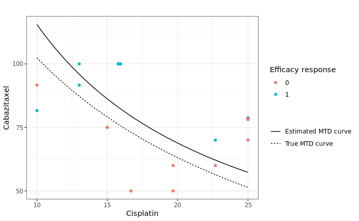

```r
true_mtd_df = data.frame(x = x_grid) %>%
  mutate(y_mtd = twodimmtd2(trho00_st1, trho01_st1, trho10_st1, talpha3_st1,theta,x),
         curve = "True MTD curve")


est_mtd_df = data.frame(x = x_grid) %>%
  mutate(y_mtd = twodimmtd2(post_rho00, post_rho01, post_rho10, post_alpha3,theta,x),
         curve = "Estimated MTD curve")

mtd_stage1_df = rbind(true_mtd_df, est_mtd_df)

eff_stage1_df = data.frame(x = doseX1, y = doseY1, E = as.factor(NEff.stg1))

ggplot(mtd_stage1_df, aes(x = x, y = y_mtd, linetype = curve)) +
  geom_line() +
  scale_x_continuous("Cisplatin",breaks = c(0,1/3,2/3,1),labels = function(x){round(x*(Xmax - Xmin) + Xmin,0)}) +
  scale_y_continuous(name = "Cabazitaxel", labels = function(y){y*(Ymax - Ymin) + Ymin}) +
  theme_bw() +
  labs(title = "", linetype = "", color = "Efficacy response") +
  geom_point(eff_stage1_df, mapping = aes(x = x, y = y, linetype = NULL, color = E)) +
  theme(legend.position = "right",
        legend.text = element_text(size = 9),
        legend.background = element_rect(fill="transparent"),
        legend.key = element_rect(fill="transparent"))
```

We now proceed with stage II. Mind that in this stage, the estimated MTD from stage I is not updated. Following the original design from Tighiouart (2019), we first allocate 10 patients across the MTD to collect efficacy along the estimated MTD. After these 10 patients, we do adaptive randomization where we allow to share efficacy data across stages.

```r
#We first see in which interval the MTD is defined for X.
mtd_data_frame = data.frame(x = x_grid) %>%
  mutate(y = twodimmtd2(post_rho00,post_rho01,post_rho10,post_alpha3, theta = theta, x = x),
         y = ifelse(y < 0, 0, ifelse(y > 1, 1, y)))

#We now know the in what interval X is defined. We allocate 10 patients equally spaced along the MTD
xx1 = seq(0,1,length.out = NN_2_fixed)
yy1 = twodimmtd2(post_rho00,post_rho01,post_rho10,post_alpha3, theta = theta, x = xx1)
yy1 = ifelse(yy1 < 0, 0, ifelse(yy1 > 1, 1, yy1))

doseX2 =  xx1
doseY2 =  yy1
Ncomb2 = NN_2_fixed
NEff.stg2 = numeric()

#We generate safety and efficacy outputs for the 10 patients placed along the MTD curve
for(i in 1:NN_2_fixed){
  NEff.stg2[i] = resp_efficacy_st2(x = xx1[i], y = yy1[i])
}

data_jags = list('NEff.stg1' = NEff.stg1, 'doseX1' = doseX1, 'doseY1' = doseY1, 'Ncomb1' = Ncomb1,
                 'NEff.stg2' = NEff.stg2, 'doseX2' = doseX2, 'doseY2' = doseY2, 'Ncomb2' = Ncomb2,
                 'wMix' = wMix)

j=jags.model('stage2_EXNEX.bug.txt',data= data_jags, n.chains=chains,n.adapt=burn,quiet = TRUE)
s=coda.samples(j,c('beta02','beta12','beta22','beta32','prob.ex'),mm,progress.bar="none")
ss=as.data.frame(s[[1]])

post_beta0_st2 = median(ss$beta02)
post_beta1_st2 = median(ss$beta12)
post_beta2_st2 = median(ss$beta22)
post_beta3_st2 = median(ss$beta32)
post_prob.ex = mean(ss$`prob.ex[1]`)

for(c2 in 1:(NN_2/m_cohort)){

  #The MTD is updated after each cohort of m_cohort patients
  integrate_peff = function(x){
    y_mtd = twodimmtd2(post_rho00,post_rho01,post_rho10,post_alpha3,theta,x)
    y_mtd = ifelse(y_mtd < 0, 0, ifelse(y_mtd > 1, 1, y_mtd))
    p = peff(post_beta0_st2,post_beta1_st2,post_beta2_st2,post_beta3_st2,x,y_mtd)
    return(p)

  }

  ncst<-integrate(integrate_peff,0,1)$value

  #Get the maximum value of the density integrate_peff

  tempmax = dplyr::pull(data.frame(x_grid = x_grid) %>%
                          mutate(y = integrate_peff(x_grid)) %>%
                          summarise(tempmax = max(y)))

  M<-(1/ncst)*tempmax

  #Sample from the standardized density based on the rejection-sampling principle.

  T = data.frame(sample.x = runif(600,0,1),
                 U = runif(600,0,1)) %>%
    mutate(rejection_boundary = (1/ncst)*integrate_peff(sample.x),
           density_sample_value = dunif(sample.x, 0, 1)*M*U,
           acceptance = ifelse(density_sample_value <= rejection_boundary, "Yes", "No")) %>%
    filter(acceptance == "Yes")

  T = T %>% dplyr::select(sample.x) %>% slice(1:m_cohort)

  T = T %>% mutate(y = twodimmtd2(post_rho00,post_rho01,post_rho10,post_alpha3,theta,sample.x),
                   y = ifelse(y < 0, 0, ifelse(y > 1, 1, y)))


  xx1 = T$sample.x
  yy1 = T$y

  for (ii in 1:m_cohort){

    ee1 = resp_efficacy_st2(tbeta0_st2, tbeta1_st2, tbeta2_st2, tbeta3_st2, x = xx1[ii], y = yy1[ii])

    NEff.stg2 = c(NEff.stg2,ee1)
    doseX2 =  c(doseX2,xx1[ii])
    doseY2 =  c(doseY2,yy1[ii])

  }

  Ncomb2 = length(doseX2)

  list('NEff.stg1' = NEff.stg1, 'doseX1' = doseX1, 'doseY1' = doseY1, 'Ncomb1' = Ncomb1,
       'NEff.stg2' = NEff.stg2, 'doseX2' = doseX2, 'doseY2' = doseY2, 'Ncomb2' = Ncomb2,
       'wMix' = wMix)

  j=jags.model('stage2_EXNEX.bug.txt',data= data_jags, n.chains=chains,n.adapt=burn,quiet = TRUE)
  s=coda.samples(j,c('beta02','beta12','beta22','beta32','prob.ex'),mm,progress.bar="none")
  ss=as.data.frame(s[[1]])

  post_beta0_st2 = median(ss$beta02)
  post_beta1_st2 = median(ss$beta12)
  post_beta2_st2 = median(ss$beta22)
  post_beta3_st2 = median(ss$beta32)
  post_prob.ex = mean(ss$`prob.ex[1]`)

  post_prob_eff = function(x){
    y_mtd = twodimmtd2(post_rho00,post_rho01,post_rho10,post_alpha3,theta,x)
    y_mtd = ifelse(y_mtd < 0, 0, ifelse(y_mtd > 1, 1, y_mtd))

    df_posterior = data.frame(beta02=ss$beta02,beta12=ss$beta12,beta22=ss$beta22,beta32=ss$beta32, x = x, y = y_mtd) %>%
      mutate(peff = peff(beta02,beta12,beta22,beta32,x,y),
             condition = ifelse(peff > null_p,1,0)) %>%
      summarise(out = mean(condition))
    return(df_posterior$out)
  }
  interim_prob_eff = max(as.numeric(lapply(x_grid, post_prob_eff)))

}
```

```
Adaptation incomplete
```

```
NOTE: Stopping adaptation
```

```
Adaptation incomplete
```

```
NOTE: Stopping adaptation
```

```r
post_prob_eff = function(x){
  y_mtd = twodimmtd2(post_rho00,post_rho01,post_rho10,post_alpha3,theta,x)
  y_mtd = ifelse(y_mtd < 0, 0, ifelse(y_mtd > 1, 1, y_mtd))

  df_posterior = data.frame(beta02=ss$beta02,beta12=ss$beta12,beta22=ss$beta22,beta32=ss$beta32, x = x, y = y_mtd) %>%
    mutate(peff = peff(beta02,beta12,beta22,beta32,x,y),
           condition = ifelse(peff > null_p,1,0)) %>%
    summarise(out = mean(condition))
  return(df_posterior$out)
}
posterior_prob_efficacy = as.numeric(lapply(x_grid, post_prob_eff))
max_posterior_prob_efficacy = max(posterior_prob_efficacy)
```

Stage II is now over. We first display the (binary) efficacy data along the MTD estimated at the end of stage I.

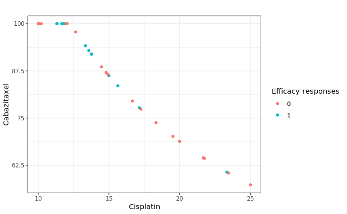

```r
data_stage2_df = data.frame(x = doseX2,
                            y = doseY2,
                            E = as.factor(NEff.stg2))

ggplot(data_stage2_df, aes(x = x, y = y, color = E)) +
  geom_point() +
  scale_x_continuous("Cisplatin",breaks = c(0,1/3,2/3,1),labels = function(x){round(x*(Xmax - Xmin) + Xmin,0)}) +
  scale_y_continuous(name = "Cabazitaxel", labels = function(y){y*(Ymax - Ymin) + Ymin}) +
  theme_bw() +
  labs(title = "", color = "Efficacy responses") +
  theme(legend.position = "right",
        legend.text = element_text(size = 9),
        legend.background = element_rect(fill="transparent"),
        legend.key = element_rect(fill="transparent"))
```

Now, we present the posterior probability of having a probability of efficacy above the one from the standard treatment of care $(p_0)$ along the estimated MTD curve. The optimal dose combination corresponds to the combination that, along the estimated MTD curves, maximizes this posterior probability.

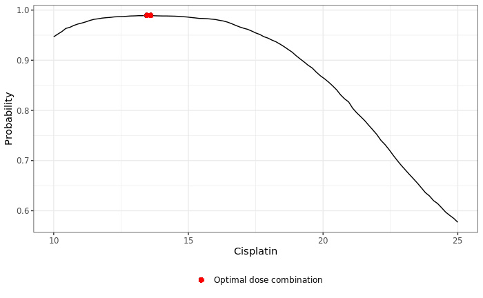

```r
post_prob_efficacy_df = data.frame(x = x_grid, post_peff = posterior_prob_efficacy)

optimal_dose_combination_df = post_prob_efficacy_df %>% filter(post_peff == max(post_peff))

ggplot(post_prob_efficacy_df, aes(x = x, y = post_peff)) +
  geom_line() +
  scale_x_continuous("Cisplatin",breaks = c(0,1/3,2/3,1),labels = function(x){round(x*(Xmax - Xmin) + Xmin,0)}) +
  scale_y_continuous(name = "Probability") +
  theme_bw() +
  geom_point(optimal_dose_combination_df, mapping = aes(x = x, y = post_peff, shape = "Optimal dose combination"), colour = "red", size = 2.5) +
  labs(shape = "") +
  theme(legend.position = "bottom",
        legend.text = element_text(size = 9),
        legend.background = element_rect(fill="transparent"),
        legend.key = element_rect(fill="transparent"))
```